# Assignment 3: MATH 4753

Dan Groeneveld

Monday, October 26, 2020

## 16/16 Questions answered

## 1-Phishing attacks to email accounts

### a.

The rate = 1/mean

```r
1 - pexp(120, 1/95)
```

```
## [1] 0.2827597
```

### b.

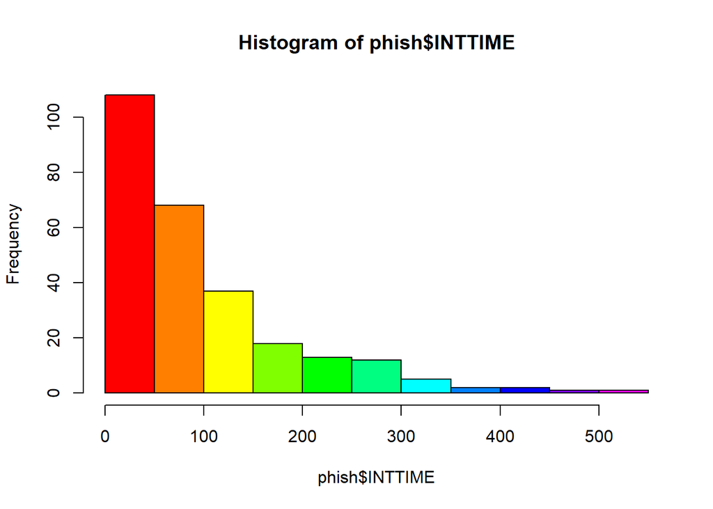

```r
phish = read.csv("PHISHING.csv")
#phish
hist(phish$INTTIME, col =rainbow(12))
```

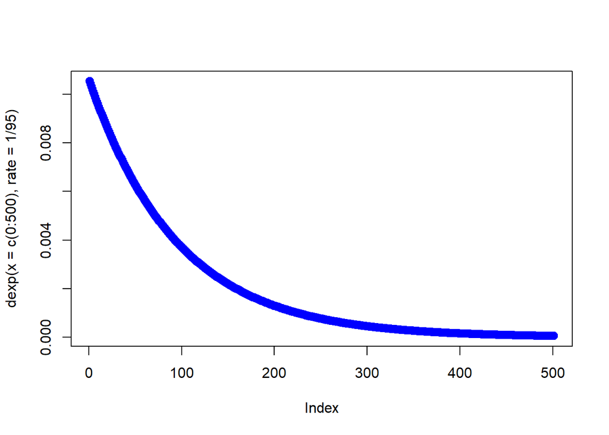

```r
plot(dexp(x = c(0:500), rate = 1/95),col="Blue",lwd=3)
```

Yes, the data appear to follow an exponential distribuion with beta = 95 as demonstrated with the two graphs above.

## 2-Flood level analysis

### a.

```r
mean = 3 *0.07
var = 3 * 0.07^2
mean
```

```
## [1] 0.21
```

```r
var
```

```
## [1] 0.0147
```

### b.

```r
mean + 3*var
```

```
## [1] 0.2541
```

A value of 0.6 million cubic feet per second would be much higher than I would expect from the 4-year period observed. From this I conclude that the max flood-level distribution is much less than that of the following 4-year period.

## 3-Reaction to tear gas

### a.

```r
muA = 2*2
muB = 4*1
muA
```

```
## [1] 4
```

```r
muB
```

```
## [1] 4
```

### b.

```r
varA = 2*2^2
varB = 1*4^2
varA
```

```
## [1] 8
```

```r
varB
```

```
## [1] 16
```

### c.

```r
pgamma(1, shape =2, scale =2) #A
```

```
## [1] 0.09020401
```

```r
pgamma(1, shape =1, scale =4) #B
```

```
## [1] 0.2211992
```

Tear gas B is more likely to produce a reaction in under a minute.

## 4-Washing machine repair time

### a.

```r
pweibull(2, shape =4, scale =2)
```

```
## [1] 0.6321206
```

### b.

```r
mean = 4^(1/2)*gamma((2 + 1)/2)
mean
```

```
## [1] 1.772454
```

```r
sd = sqrt(4^(2/2)*(gamma((2+2)/2) - (gamma(3/2))^2))
sd
```

```
## [1] 0.9265028
```

### c.

```r
mean + 2*sd
```

```
## [1] 3.625459
```

```r
mean - 2*sd
```

```
## [1] -0.08055165
```

```r
pweibull(mean + 2*sd, shape =4, scale =2) - pweibull(mean - 2*sd, shape =4, scale =2)
```

```
## [1] 0.9999796
```

### d.

```r
1 - pweibull(6, shape =4, scale =2)
```

```
## [1] 0
```

No, it is not likely that y will exceed 6 as the probability that y is greater than 6 is zero.

## 5-Laser color printer repairs

### a.

```r
mean = 2/(2 +9)
var = (2 * 9)/((2 + 9)^2*(2 + 9 +1))
mean
```

```
## [1] 0.1818182
```

```r
var
```

```
## [1] 0.01239669
```

### b.

```r
1 - pbeta(0.4, 2, 9)
```

```
## [1] 0.0463574
```

### c.

```r
pbeta(.1, 2, 9)
```

```
## [1] 0.2639011
```

## 6-Lifelengths of memory chips

### a.

alpha = 2

beta = 16

### b.

```r
mean = 16^(1/2)*gamma((2 + 1)/2)
var = 16^(2/2)*(gamma((2+2)/2) - (gamma(3/2))^2)
mean
```

```
## [1] 3.544908
```

```r
var
```

```
## [1] 3.433629
```

### c.

```r
1 - pweibull(6, shape =2, scale =4)
```

```
## [1] 0.1053992
```

## 7-Tossing dice

### a.

```r
x = c(1/6, 1/6, 1/6, 1/6, 1/6, 1/6)
y = c(1/6, 1/6, 1/6, 1/6, 1/6, 1/6)
probdist = matrix(c(x*y), nc = 6, nr =6, dimnames =list(c("x=1","x=2","x=3","x=4","x=5","x=6"), c("y=1","y=2","y=3","y=4","y=5","y=6")))
addmargins(probdist)
```

```
##            y=1        y=2        y=3        y=4        y=5        y=6       Sum
## x=1 0.02777778 0.02777778 0.02777778 0.02777778 0.02777778 0.02777778 0.1666667
## x=2 0.02777778 0.02777778 0.02777778 0.02777778 0.02777778 0.02777778 0.1666667
## x=3 0.02777778 0.02777778 0.02777778 0.02777778 0.02777778 0.02777778 0.1666667
## x=4 0.02777778 0.02777778 0.02777778 0.02777778 0.02777778 0.02777778 0.1666667
## x=5 0.02777778 0.02777778 0.02777778 0.02777778 0.02777778 0.02777778 0.1666667
## x=6 0.02777778 0.02777778 0.02777778 0.02777778 0.02777778 0.02777778 0.1666667
## Sum 0.16666667 0.16666667 0.16666667 0.16666667 0.16666667 0.16666667 1.0000000
```

### b.

p1(x) = sum(x=n)= 1/6 or 0.166667

p2(y) = sum(y=n)=1/6 or 0.166667

### c.

p1(x|y) = p(x,y)/p2(y) = (1/36)/(1/6) = 1/6 or 0.16667

p2(y|x) = p(x,y)/p1(x) = (1/36)/(1/6) = 1/6 or 0.16667

### d.

I have observed the phenomenon that both of these probability distributions are the same.

## 8-Modeling the behavior of granular media

### a.

The bivariate probability distribution.

```r
probdist = matrix(c(1/7,0,0,2/7,0,0,1/7,2/7,1/7), nr= 3, nc=3, dimnames = list(c("y=1","y=2","y=3"),c("x=1","x=2","x=3")))
addmargins(probdist)
```

```
##           x=1       x=2       x=3       Sum
## y=1 0.1428571 0.2857143 0.1428571 0.5714286
## y=2 0.0000000 0.0000000 0.2857143 0.2857143
## y=3 0.0000000 0.0000000 0.1428571 0.1428571
## Sum 0.1428571 0.2857143 0.5714286 1.0000000
```

### b.

p1(x)

```r
p1x = matrix(c(1/7,2/7,4/7), nc=3, nr=1, dimnames = list(c("p1(x)"),c("x=1","x=2","x=3")))
p1x
```

```
##             x=1       x=2       x=3
## p1(x) 0.1428571 0.2857143 0.5714286
```

### c.

p2(y)

```r
p2y = matrix(c(4/7,2/7,1/7), nc=3, nr=1, dimnames = list(c("p2(y)"),c("y=1","y=2","y=3")))
p2y
```

```
##             y=1       y=2       y=3
## p2(y) 0.5714286 0.2857143 0.1428571
```

### d.

```r
x1 = c((1/7)/(1/7), 0/(1/7), 0/(1/7)) #calculating the probabilities for each conditional probability
x2 = c((1/7)/(1/7), 0/(1/7), 0/(1/7))
x3 = c((1/7)/(4/7), (2/7)/(4/7),(1/7)/(4/7))
probdist = matrix(c(x1,x2,x3), nr= 3, nc=3, dimnames = list(c("y=1","y=2","y=3"),c("p2(y|1)","p2(y|2)","p2(y|3)")), byrow = FALSE)
probdist
```

```
##     p2(y|1) p2(y|2) p2(y|3)
## y=1       1       1    0.25
## y=2       0       0    0.50
## y=3       0       0    0.25
```

## 9-Distribution of low bids

### a.

f(y) was calculated on paper and the final result is presented below.

$$f(y) = \frac{e^\frac{-y}{10}}{10}$$

This is equal to an exponential distirbution with beta = 10.

### b.

The mean DOT estimate is equal to E(y) = E((exp(beta=10))) = E(exp(beta=10)) = 10.

The mean DOT estimate is $10,000.

## 10-Servicing an automobile

### a.

Solving:

$$\int_0^\infty{\int_0^x{ce^{-x^2}dydx}} = 1$$

yields:

c= 2.

### b.

The marginal density for x is:

$$f_1(x) =2xe^{-x^2}$$

Integrating the density from negative to positve infinity yields:

$$-e^{-\infty^2}-e^{0^2} = 1$$

### c.

After calculation, it can be seen the result is a uniform density (1/x) for the interval where y is between 0 and x.

$$f_2(x|y) = \frac{f(x,y)}{f_1(x)} = \frac{2e^{-x^2}}{2xe^{-x^2}} = \frac{1}{x}$$

## 11-Converse of Theorem 6.6

```r
probdist = matrix(c(1/12,2/12,1/12,2/12,0,2/12,1/12,2/12,1/12), nr= 3, nc=3, dimnames = list(c("y=-1","y=0","y=1"),c("x=-1","x=0","x=1")))
addmargins(probdist)
```

```
##            x=-1       x=0        x=1       Sum
## y=-1 0.08333333 0.1666667 0.08333333 0.3333333
## y=0  0.16666667 0.0000000 0.16666667 0.3333333
## y=1  0.08333333 0.1666667 0.08333333 0.3333333
## Sum  0.33333333 0.3333333 0.33333333 1.0000000
```

E(xy)

```r
1/12 +0 + -1/12 + 0 + 0 + 0 + -1/12 + 0 + 1/12
```

```
## [1] 0
```

E(x)

```r
-1*1/3 +0*1/3 + 1*1/3
```

```
## [1] 0
```

E(y)

```r
-1*1/3 + 0*1/3 +1*1/3
```

```
## [1] 0
```

The covariance of x and y, E(xy) - E(x)E(y) = 0.

However, the probability that x=0 and y=0 (p(x,y)) is not equal to the product of the probability that x = 0 (p1(x)) and y = 0 (p2(y)). To show this, p(x=0,y=0)= 0, but p1(x=0) = 1/3 and p2(y=0) =1/3. The product p1(x=0)*p2(y=0) = 1/9, which is not equal to zero. Therefore the converse of Theorem of 6.6 is not true.

## 12-Uranium in the Earth’s crust

### a.

$$E(\bar{Y}) = \mu = \frac{a + b}{2}$$

```r
(1 + 3)/2
```

```
## [1] 2
```

### b.

$$Var(\bar{Y}) =\frac{\sigma^2}{n} = \frac{(b-a)^2}{12n}$$

```r
(3-1)^2/12/60
```

```
## [1] 0.005555556
```

### c.

The shape of the sampling distribution of y bar will approach a normal distribution with mean mu and variance sigma squared over n as n tends toward infinity.

### d.

```r
pnorm(2.5, 2, sqrt(0.00555556)) - pnorm(1.5, 2, sqrt(0.00555556))
```

```
## [1] 1
```

### e.

```r
1 - pnorm(2.2, 2, sqrt(0.00555556))
```

```
## [1] 0.003645191
```

## 13-Mercury contamination in swordfish

### a.

given u = np

and sigma = sqrt(npq)

Applying the continuity correction:

```r
pnorm(1.5, 20*0.4, sqrt(20*0.4*0.6))
```

```
## [1] 0.001504434
```

### b.

```r
1 -pnorm(10.5, 20*0.4, sqrt(20*0.4*0.6))
```

```
## [1] 0.1269165
```

### c.

```r
pbinom(1, 20, 0.4)
```

```
## [1] 0.0005240494
```

```r
1 - pbinom(10, 20, 0.4)
```

```
## [1] 0.1275212
```

## 14-Lead and copper in drinking water

### a.

```r
read.csv("LEADCOPP.csv")-> leadcop

t.test(leadcop$LEAD,conf.level = 0.99)
```

```
##
##  One Sample t-test
##
## data:  leadcop$LEAD
## t = 2.325, df = 9, p-value = 0.04512
## alternative hypothesis: true mean is not equal to 0
## 99 percent confidence interval:
##  -1.147845  6.919045
## sample estimates:
## mean of x
##    2.8856
```

### b.

```r
t.test(leadcop$COPPER,conf.level = 0.99)
```

```
##
##  One Sample t-test
##
## data:  leadcop$COPPER
## t = 5.1746, df = 9, p-value = 0.0005836
## alternative hypothesis: true mean is not equal to 0
## 99 percent confidence interval:
##  0.1518726 0.6647274
## sample estimates:
## mean of x
##    0.4083
```

### c.

This means that there is 99% confidence that the lead levels will fall between -1.15 and 6.92 micrograms/L and that copper levels will fall between 0.1519 and 0.6647 mg/L.

### d.

99% confident means that there is a 99% chance all of the measurements in a sample will fall within the interval given.

## 15-Solar irradiation study

```r
solrad = read.csv("SOLARAD.csv")
with(solrad, t.test(STJOS, IOWA, paired=TRUE, conf.level = 0.95))
```

```
##
##  Paired t-test
##
## data:  STJOS and IOWA
## t = 11.765, df = 6, p-value = 2.277e-05
## alternative hypothesis: true difference in means is not equal to 0
## 95 percent confidence interval:
##  156.8193 239.1807
## sample estimates:
## mean of the differences
##                     198
```

## 16-Diazinon residue in orchards

### a.

```r
diazinon = read.csv("DIAZINON.csv")
with( diazinon, t.test(DAY, NIGHT, paired =TRUE, conf.level = 0.90))
```

```
##
##  Paired t-test
##
## data:  DAY and NIGHT
## t = -3.5278, df = 10, p-value = 0.005467
## alternative hypothesis: true difference in means is not equal to 0
## 90 percent confidence interval:
##  -58.89917 -18.91901
## sample estimates:
## mean of the differences
##               -38.90909
```

### b.

The assumptions necessary for part a are that the population is normal.

### c.

Using part a, there is a mean difference of -38.909 mg/m^3. To answer the question, yes there is a difference between the mean diazinon levels from night to day.